# 【写経】因果関係と相関関係

ken.nakano

2017/10/13

この記事を写経するだけのスクリプト  
http://takehiko-i-hayashi.hatenablog.com/entry/20130919/1379560929#f19

# 因果関係があるのに相関関係が見られない(1)

## 仮想データの作成

```r
# サンプルサイズを5000に設定
n.sample <- 5000

# 平均0, 標準偏差1の正規分布から5000個の「水田面積」の値をランダムに生成
suiden.v <- rnorm(n.sample, mean=0, sd=1)

# 平均0, 標準偏差1の正規分布から誤差項を作成
error1.v <- rnorm(n.sample, mean=0, sd=1)

# 「農薬濃度=1.0×水田面積+誤差」から農薬濃度の値を生成, 標準化
nouyaku.v <- 1.0*suiden.v + error1.v
nouyaku.v <- scale(nouyaku.v)

# 平均0, 標準偏差1の正規分布から誤差項を作成
error2.v <- rnorm(n.sample, mean=0, sd=1)

# 「生物種数=0.5×水田面積 - 0.3×農薬濃度 + 誤差」から生物種数を生成
seibutsu.v <- 0.5*suiden.v - 0.3*nouyaku.v + error2.v


# 生成したデータをまとめる
data <- data.frame(
  syusuu = seibutsu.v,
  nouyaku = nouyaku.v,
  suiden = suiden.v
)

head(data,10)
```

```
FALSE        syusuu      nouyaku      suiden
FALSE 1   1.0384039 -0.377227144 -0.07567116
FALSE 2  -2.3021917 -1.362890171 -1.33994730
FALSE 3  -0.3723070  0.005254564  0.29699754
FALSE 4  -0.2745688 -0.857122076 -0.50308608
FALSE 5   0.8361457  0.796185234  1.89151623
FALSE 6   1.5281049 -0.896370793  0.66032564
FALSE 7  -0.2709020 -2.636555434 -2.35395098
FALSE 8   0.1079084  1.271923409  0.66112866
FALSE 9  -1.1540081 -0.404761196 -0.36745915
FALSE 10  1.1290858  0.045576963  1.38109735
```

これで、

- 水田面積UP → 生物種数UP
- 水田面積UP → 農薬濃度UP
- 農薬濃度UP → 生物種数DOWN

のデータが作成できた。

## データを眺める

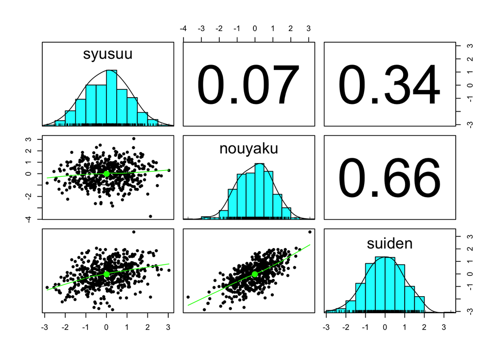

```r
pairs.panels(data[1:500,], col="green", pch=20, ps=0.1)
```

ここで、事態を理解するために回帰分析を適用してみる

```r
fit.lm.1 <- lm(syusuu ~ nouyaku, data=data)
summary(fit.lm.1)
```

```
FALSE
FALSE Call:
FALSE lm(formula = syusuu ~ nouyaku, data = data)
FALSE
FALSE Residuals:
FALSE     Min      1Q  Median      3Q     Max
FALSE -4.3008 -0.7327 -0.0037  0.7325  4.1048
FALSE
FALSE Coefficients:
FALSE             Estimate Std. Error t value Pr(>|t|)
FALSE (Intercept)  0.01752    0.01498    1.17    0.242
FALSE nouyaku      0.05870    0.01498    3.92 8.99e-05 ***
FALSE ---
FALSE Signif. codes:  0 '***' 0.001 '**' 0.01 '*' 0.05 '.' 0.1 ' ' 1
FALSE
FALSE Residual standard error: 1.059 on 4998 degrees of freedom
FALSE Multiple R-squared:  0.003065,    Adjusted R-squared:  0.002865
FALSE F-statistic: 15.36 on 1 and 4998 DF,  p-value: 8.987e-05
```

生物種数と農薬濃度の単回帰の結果は、

- 回帰係数：0.05とか
- p値<.01（これは記事と異なる部分）

で、実際の効果（生物種数=0.5×水田面積 - 0.3×農薬濃度 + 誤差）よりも桁が1つ少なく、かつ符号が逆になっている。

これは水田面積が交絡因子として作用しているからで、交絡を調整するには、交絡因子を説明変数に追加して回帰すればよい。

```r
fit.lm.2 <- lm(syusuu ~ nouyaku + suiden, data=data)
summary(fit.lm.2)
```

```
FALSE
FALSE Call:
FALSE lm(formula = syusuu ~ nouyaku + suiden, data = data)
FALSE
FALSE Residuals:
FALSE     Min      1Q  Median      3Q     Max
FALSE -3.6948 -0.6726  0.0125  0.6783  3.5814
FALSE
FALSE Coefficients:
FALSE             Estimate Std. Error t value Pr(>|t|)
FALSE (Intercept)  0.02195    0.01412   1.555     0.12
FALSE nouyaku     -0.29506    0.01997 -14.773   <2e-16 ***
FALSE suiden       0.49349    0.01971  25.041   <2e-16 ***
FALSE ---
FALSE Signif. codes:  0 '***' 0.001 '**' 0.01 '*' 0.05 '.' 0.1 ' ' 1
FALSE
FALSE Residual standard error: 0.9982 on 4997 degrees of freedom
FALSE Multiple R-squared:  0.1142,  Adjusted R-squared:  0.1139
FALSE F-statistic: 322.2 on 2 and 4997 DF,  p-value: < 2.2e-16
```

推定結果が元のデータ生成式（生物種数=0.5×水田面積 - 0.3×農薬濃度 + 誤差）とかなり近いことがわかる。

ここまでは普通の交絡の話。問題はここから。

# 因果関係があるのに相関関係が見られない(2)

## 仮想データの作成

```r
# サンプルサイズを5000に設定
n.sample <- 5000

# それぞれの能力値を平均ゼロ、標準偏差1の正規分布に従いランダムに生成
bike_ability.v <- rnorm(n.sample,mean=0,sd=1)
run_ability.v <- rnorm(n.sample,mean=0,sd=1)
swim_ability.v <- rnorm(n.sample,mean=0,sd=1)

# 誤差項の作成
error1.v <- rnorm(n.sample,mean=0,sd=1)

# デュアスロンタイムデータを「デュアスロンタイム＝ -0.5×自転車力 - 1.5×走力 ＋ 誤差」の関係式により作成
duathlon_time.v <- -0.5*bike_ability.v -  1.5*run_ability.v + error1.v

# 誤差項の作成
error2.v <- rnorm(n.sample,mean=0,sd=1)

# トライアスロンタイムデータを「トライアスロンタイム＝ -1×自転車力 - 0.5×走力 - 0.5×泳力＋ 誤差」の関係式により作成
triathlon_time.v <- -1*bike_ability.v - 0.5*run_ability.v - 0.5*swim_ability.v + error2.v


# 生成したデータをまとめる
data <- data.frame(
  bike = bike_ability.v,
  run = run_ability.v,
  swim = swim_ability.v,
  duathlon = duathlon_time.v,
  triathlon = triathlon_time.v
)


head(data, 10)
```

```
FALSE           bike        run       swim    duathlon  triathlon
FALSE 1  -0.18532191 -1.5785659 -1.0916263  3.03367728  2.6921718
FALSE 2  -0.01207136  1.5841836 -0.8436242 -0.95319043  0.7465860
FALSE 3  -2.09368810 -0.7708289 -1.9624498  4.61868268  3.4609437
FALSE 4  -0.76220612  0.3608572  0.4207424  2.62133624 -0.8552069
FALSE 5  -1.13322533 -0.2182688  1.0933394 -0.78523809  0.4138995
FALSE 6  -0.91681251  0.7593126 -1.1546802  0.44997085  1.8309131
FALSE 7  -1.63486867 -1.8400979 -0.1956778  4.33878997  1.5861091
FALSE 8   0.28859216 -0.1825991  0.3430236  0.09471792  0.9322468
FALSE 9   0.53644816 -1.5418431  0.9101676  1.58569150  0.7995504
FALSE 10 -0.44537966 -0.3305914 -1.0977080  0.87302225  2.9433441
```

## データを眺める

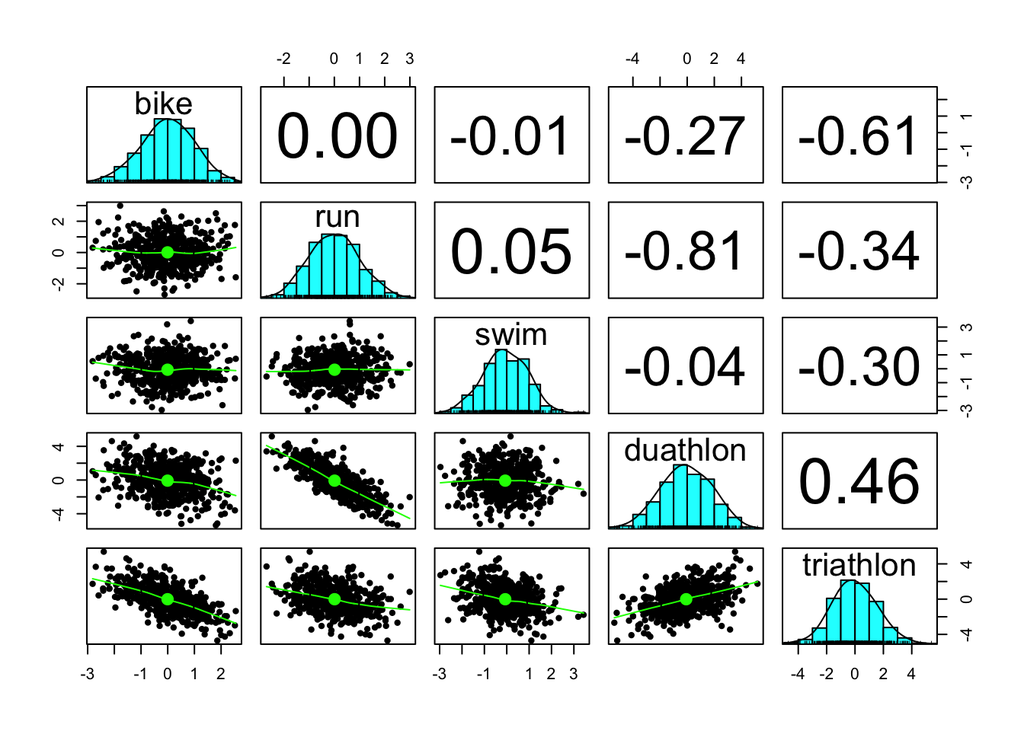

```r
pairs.panels(data[1:500,], col="green", pch=20, ps=0.1)
```

この散布図を見ると、

- bike,runとdua,triに負の相関
- bike,runには相関なし

で、作成したデータの特徴となんら矛盾のないもの。

これに対して回帰分析を適用する。

```r
# デュアスロンタイム ~ 自転車力の単回帰
fit.lm.1 <- lm(duathlon ~ bike, data=data)
summary(fit.lm.1)
```

```
FALSE
FALSE Call:
FALSE lm(formula = duathlon ~ bike, data = data)
FALSE
FALSE Residuals:
FALSE     Min      1Q  Median      3Q     Max
FALSE -6.1342 -1.2130 -0.0259  1.1867  5.6725
FALSE
FALSE Coefficients:
FALSE             Estimate Std. Error t value Pr(>|t|)
FALSE (Intercept) -0.02946    0.02511  -1.173    0.241
FALSE bike        -0.51539    0.02496 -20.652   <2e-16 ***
FALSE ---
FALSE Signif. codes:  0 '***' 0.001 '**' 0.01 '*' 0.05 '.' 0.1 ' ' 1
FALSE
FALSE Residual standard error: 1.776 on 4998 degrees of freedom
FALSE Multiple R-squared:  0.07862, Adjusted R-squared:  0.07844
FALSE F-statistic: 426.5 on 1 and 4998 DF,  p-value: < 2.2e-16
```

単回帰の結果は、元々のデータ生成時の関係式における係数「-0.5」に近い値になっており、「自転車→デュアスロンタイム」の因果効果を適切に推定している。つまりこの例では単回帰で十分ということ。

次に、このケースに対して重回帰分析を行う。 ただし、変数として「走力」が測定されておらず、代わりに「トライアスロンタイム」のデータだけがある状況を考える。

そして、とりあえず*「説明変数（自転車力）と関連のありそうな変数はモデルに入れておく」*という方針で、

```r
fit.lm.2 <- lm(duathlon ~ bike + triathlon, data=data)
summary(fit.lm.2)
```

```
FALSE
FALSE Call:
FALSE lm(formula = duathlon ~ bike + triathlon, data = data)
FALSE
FALSE Residuals:
FALSE     Min      1Q  Median      3Q     Max
FALSE -5.2433 -1.1420 -0.0142  1.1052  5.7197
FALSE
FALSE Coefficients:
FALSE             Estimate Std. Error t value Pr(>|t|)
FALSE (Intercept) -0.02815    0.02370  -1.188    0.235
FALSE bike        -0.02925    0.03065  -0.954    0.340
FALSE triathlon    0.48336    0.01950  24.792   <2e-16 ***
FALSE ---
FALSE Signif. codes:  0 '***' 0.001 '**' 0.01 '*' 0.05 '.' 0.1 ' ' 1
FALSE
FALSE Residual standard error: 1.676 on 4997 degrees of freedom
FALSE Multiple R-squared:  0.1795,  Adjusted R-squared:  0.1792
FALSE F-statistic: 546.7 on 2 and 4997 DF,  p-value: < 2.2e-16
```

この解析の結果、自転車力の偏回帰係数は元々のデータ生成時の関係式における係数「-0.5」とは全く異なり、有意差も消えてしまっている。

つまり、トライアスロンのタイムを加えることにより、「自転車力→デュアスロンタイム」の因果効果がすっかり見えなくなってしまったということ。

じつは、このケースでは合流点であるトライアスロンタイムを加えることで、走力が交絡因子へと変化してしまう。

※なので、さらに走力を説明変数に加えると

```r
fit.lm.3 <- lm(duathlon ~ bike + run + triathlon, data=data)
summary(fit.lm.3)
```

```
FALSE
FALSE Call:
FALSE lm(formula = duathlon ~ bike + run + triathlon, data = data)
FALSE
FALSE Residuals:
FALSE     Min      1Q  Median      3Q     Max
FALSE -3.4096 -0.6805  0.0002  0.6840  3.5626
FALSE
FALSE Coefficients:
FALSE              Estimate Std. Error t value Pr(>|t|)
FALSE (Intercept) -0.005551   0.014218  -0.390   0.6962
FALSE bike        -0.535067   0.019150 -27.941   <2e-16 ***
FALSE run         -1.478186   0.015676 -94.298   <2e-16 ***
FALSE triathlon   -0.022149   0.012865  -1.722   0.0852 .
FALSE ---
FALSE Signif. codes:  0 '***' 0.001 '**' 0.01 '*' 0.05 '.' 0.1 ' ' 1
FALSE
FALSE Residual standard error: 1.005 on 4996 degrees of freedom
FALSE Multiple R-squared:  0.7049,  Adjusted R-squared:  0.7047
FALSE F-statistic:  3977 on 3 and 4996 DF,  p-value: < 2.2e-16
```

で、「デュアスロンタイム＝ -0.5×自転車力 - 1.5×走力 ＋ 誤差」に近くなる = 交絡を調整できる

※記事ではこのあとAICの議論に。「AIC最小」と「偏回帰係数が因果効果を適切に反映している」ことは本質的に別の話